# Use case: playing video games

Data Intuitive Tuesday - January 26, 2021

- Background on Civilization
- Post-game replay map
- Rendering post-game replay maps
- Step 1: Generate input files
- Step 2, `parse_header`: Extract game info
- Step 3, `parse_map`: Extract map info
- Step 4, `plot_map`: Generate map visualisation
- Step 5, `convert_plot`: Convert PDF to PNG
- Step 6, `combine_plots`: Create movie
- Enter viash, stage left

The application domain of [viash](https://www.data-intuitive.com/viash_docs) is not limited to just biomedical research. In this tutorial, we will solve one of our pet peeves in a video game called Sid Meier’s Civilization.

## Background on Civilization

Civilization is a series of six video strategy games where players oversee the development of a civilization, starting from the dawn of civilizations until present times. Not only is the series famous for having defined a lot of the game mechanics in the 4X genre (eXplore, eXpand, eXploit, and eXterminate), it is also frequently associated with the “One More Turn Syndrome”.

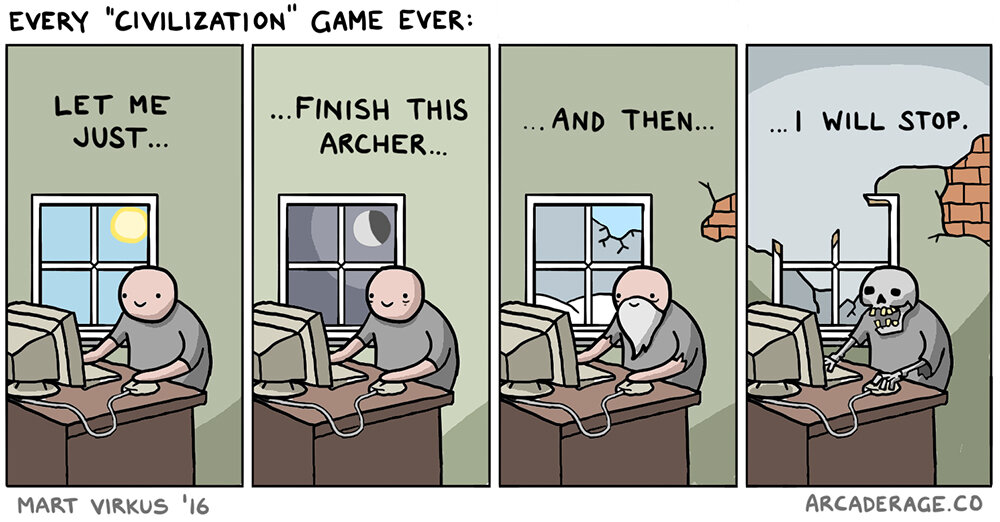

Comic by Mart Virkus, https://arcaderage.co/2016/10/18/civilization-vi/

## Post-game replay map

Multiplayer games can take a few hours to finish – anywhere between 2 to 10 hours, depending on who you’re playing with. That’s why a perfect way of closing a session of Civilization V is by being able to watch a ‘postgame map replay’ of which owner owned which time at any given point in time.

[figure not shown]

However, for whatever reason, this feature did not make it in Civilization VI. This made a lot of people very angry and been widely regarded as a bad move.

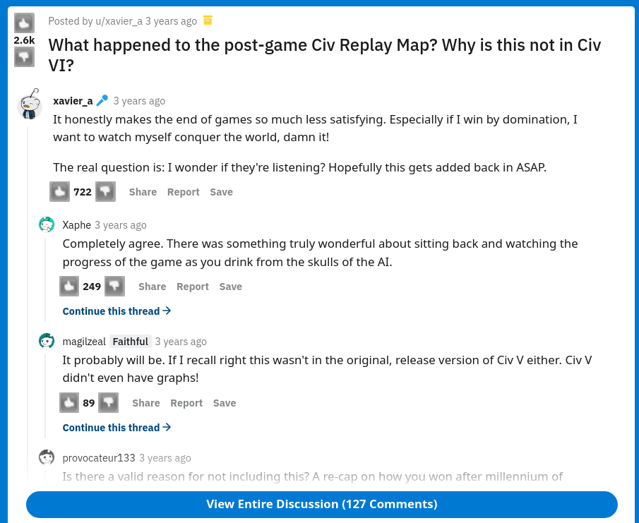

## Rendering post-game replay maps

At Data Intuitive, we’re all about alleviating people’s suffering, so we developed a few scripts for rendering a postgame video for Civilization VI using open-source tools. It works by letting the game automatically creates saves for every turn of the game (called ‘autosaves’). An autosave contains all the information to resume the game from that point in time. Since the information that we need is stored in a format, we need scripts to: 1. extract the information from the binary format (in JavaScript), 2. generate a map visualisation (in R), 3. convert all the visualisations into a video (with ImageMagick and ffmpeg).

You can see the general workflow for generating a postgame replay video in the diagram below.

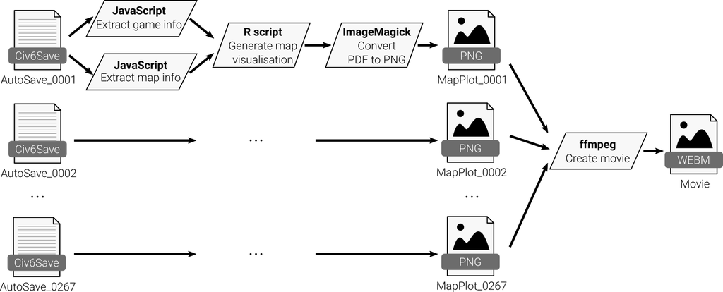

In the next sections, we briefly discuss how each component works, as it will be used later on in the tutorial.

## Step 1: Generate input files

Start up Civilization VI and go into the settings menu. You need to configure Civilization VI to create an autosave every turn, and to keep all autosaves as normally only the 10 latest autosaves are kept.

[figure not shown]

Your first task in this tutorial is to play a game of Civilization VI, yay! See you in a few hours! Don’t forget to come back for the remainder of this tutorial!

…

…

Just kidding. We did the fun part and already created autosaves for you. If you check the `data` folder, you will see five autosave files.

```bash
> ls -l data
total 6592
-rw-rw-r--. 1 rcannood rcannood  612404 Jan 26 10:42 AutoSave_0158.Civ6Save
-rw-rw-r--. 1 rcannood rcannood 1061697 Jan 26 10:42 AutoSave_0159.Civ6Save
-rw-r--r--. 1 rcannood rcannood  107948 Feb  5 11:11 AutoSave_0159.pdf
-rw-r--r--. 1 rcannood rcannood  673420 Feb  5 11:11 AutoSave_0159.png
-rw-r--r--. 1 rcannood rcannood  779029 Feb  4 17:14 AutoSave_0159.tsv
-rw-r--r--. 1 rcannood rcannood    8236 Feb  5 09:17 AutoSave_0159.yaml
-rw-rw-r--. 1 rcannood rcannood 1140352 Jan 26 10:42 AutoSave_0160.Civ6Save
-rw-rw-r--. 1 rcannood rcannood 1164860 Jan 26 10:42 AutoSave_0161.Civ6Save
-rw-rw-r--. 1 rcannood rcannood 1179409 Jan 26 10:42 AutoSave_0162.Civ6Save
```